# Tarea 1

Ortega Zapata Ximena Marian

08/03/2021

Características naturales: El café es un fruto verde, redondo, con aspecto similar al de una cereza que cuando madura se vuelve marrón. Su pulpa es roja, dulce y resbaladiza, la semilla de café contiene dos granos dentro de la pulpa que miden aproximadamente 1 cm, este fruto pertenece a las plantas rubiaceae. Se puede obtener una buena cosecha a los 5 o 6 años, pero dará fruto entre los 2 y 4 años. Cada árbol puede obtener aproximadamente 0,4 kg de granos de las variedades de café árabe y cada árbol puede obtener 0,6 kg de granos de Robusta, los árboles pueden crecer hasta los 30 años y pueden alcanzar los 80 años. La fruta tarda un tiempo en madurar y permanecer en el árbol de 6 a 9 semanas después. Los cultivos se deben recolectar varias veces y solo se toman los frutos maduros, lo que ralentiza el proceso, una vez recolectada se seca al sol y es necesario quitar los granos de la pulpa antes de que la pulpa comience a fermentar. En cuanto a su sabor, la amargura, acides y dulzura son unos de los principales detectados al consumirlo.. Su aroma puede variar de hierbas a afrutado. El café es uno de los frutos más consumidos entre las personas, no solo por su sabor, si no por los efectos que produce en ellos ya que contiene sustancias químicas que son estimulantes para los consumidores, estas sustancias químicas son toxicas en grandes dosis, causando insomnio y fatiga mental.

Valor de uso: Para que el café finalmente se consuma, debe pasar por un largo proceso, que necesita mano de obra de personas dedicadas a ello. Desde la plantación de los cafetos, cuidados, cultivo, hasta el proceso industrial en el tostado del café, esté penúltimo proceso, considerado artístico, exige poseer al experto una amplia experiencia y un cúmulo de conocimientos técnicos, para finalizar el café se muele, aunque también suele venderse en granos enteros.

Valor de cambio: La comercialización del café en México se da principalmente en 15 estados que son productores de café; al sur del país, Chiapas es el principal estado productor, aportando 41.0% del volumen nacional, seguido por Veracruz (24.0%) y Puebla 15.3%. (GOB: 2018).

Valor: Para la economía mexicana, el café es un cultivo estratégico, su producción emplea a más de 500 mil productores de 15 entidades federativas y 480 municipios. Actualmente se consumen 1.4 kg per cápita al año, exportando 28.000 toneladas, principalmente a la unión Europea. La producción de sus cafetos representa 2.4% del total mundial ocupando así el lugar 11 nivel mundial de productores de café. (GOB: 2018).

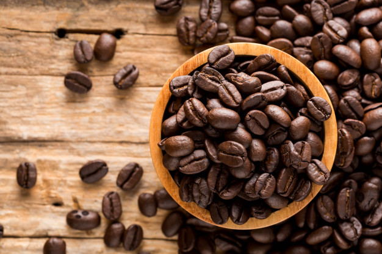

freepik

## Bibliografía

1. Secretaría de Agricultura y Desarrollo Rural (2018). México, onceavo productor mundial de café. GOB. Recuperado el 6 de marzo de 2021 de México, onceavo productor mundial de café | Secretaría de Agricultura y Desarrollo Rural | Gobierno | gob.mx (www.gob.mx)
2. SEGARPA. (2017-2030). PLANEACIÓN AGRÍCOLA NACIONAL. GOB. Recuperado el 7 de marzo de 2021 de B_sico-Caf_.pdf (www.gob.mx)